# hw0

## Part 1

- Write a Quarto document that defines variables $a=1, b=3, c=2$ and print out the solutions to $f(x) = ax^2+bx+c=0$.

```
The real roots are: -1 and -2
```

Since $ax^2+bx+c=0$ is a quadratic equation with one unknown variable, we can first calculate the discriminant $D$ which is given by the formula $D=b^2-4ac$ . The roots are then calculated using $\frac{{-b \pm \sqrt{D}}}{2a}$. If $D$ is less than 0, real roots do not exist. If $D$ is equal to 0, there is one real root. If $D$ is larger than 0, there are two distinct real roots.

## Part 2

- Include a graph of $f(x)$ versus $x$ for $x \in (-5,5)$ to verify the solutions.

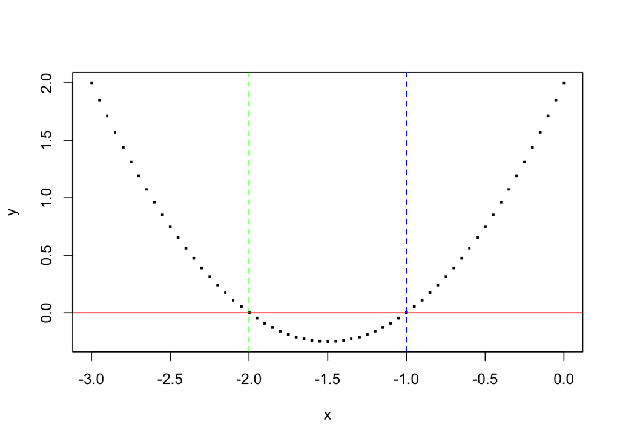

I am plotting $f(x)=ax^2+bx+c$ over a range of $x$ values that extend a little beyond its real roots. Additionally, I include a red horizontal line at $y=0$ to easily identify where the function crosses the x-axis, which are the roots of the equation $f(x)=0$. I also add vertical dashed lines at the x-coordinates corresponding to the two roots, color-coded in blue and green, to visually indicate the solutions to $f(x)$. Since the intersections of the vertical lines and the horizontal line lie on the function curve, the solutions are correct.